# AB test_price optimization

## Background

This notebook analyzes data for pricing optimization from an A/B test targeting conversion rates for an app.  
The experiment seperates visitors into two groups based on the price received, control group with lower price of 39 dollar, while test group 59 dollar.  
However, there is a trade-off between price and conversion rate.The conversion rate of group with higher price is relatively lower.

### Three main questions:

1) Which attributes of customer behavior influence conversion rate?  
2) At which price should the company list their software?  
3) How long should the experiment have taken?

### The results are summarized below:

```python
import pandas as pd
import numpy as np
import seaborn as sns
import matplotlib.pyplot as plt
import os
%matplotlib inline
```

## Load data

```python
test_results = pd.read_csv("test_results.csv")
test_results.head()
```

|  | Unnamed: 0 | user_id | timestamp | source | device | operative_system | test | price | converted |
| --- | --- | --- | --- | --- | --- | --- | --- | --- | --- |
| 0 | 0 | 604839 | 2015-05-08 03:38:34 | ads_facebook | mobile | iOS | 0 | 39.0 | 0 |
| 1 | 1 | 624057 | 2015-05-10 21:08:46 | seo-google | mobile | android | 0 | 39.0 | 0 |
| 2 | 2 | 317970 | 2015-04-04 15:01:23 | ads-bing | mobile | android | 0 | 39.0 | 0 |
| 3 | 3 | 685636 | 2015-05-07 07:26:01 | direct_traffic | mobile | iOS | 1 | 59.0 | 0 |
| 4 | 4 | 820854 | 2015-05-24 11:04:40 | ads_facebook | web | mac | 0 | 39.0 | 0 |

## Data preprocessing

```python
# check missing value
test_results.info()
```

```
<class 'pandas.core.frame.DataFrame'>
RangeIndex: 316800 entries, 0 to 316799
Data columns (total 9 columns):
 #   Column            Non-Null Count   Dtype
---  ------            --------------   -----
 0   Unnamed: 0        316800 non-null  int64
 1   user_id           316800 non-null  int64
 2   timestamp         316466 non-null  object
 3   source            316488 non-null  object
 4   device            316800 non-null  object
 5   operative_system  296461 non-null  object
 6   test              316800 non-null  int64
 7   price             316800 non-null  float64
 8   converted         316800 non-null  int64
dtypes: float64(1), int64(4), object(4)
memory usage: 21.8+ MB
```

Variables with missing values:

- timestamp
- source
- operative system

```python
print("Number of nulll value")
print("timestamp:",test_results.timestamp.isnull().sum())
print("source:",test_results.source.isnull().sum())
print("operative system:",test_results.operative_system.isnull().sum())
```

```
Number of nulll value
timestamp: 334
source: 312
operative system: 20339
```

The variable operative system has many missing value.  
It is likely that web analytics cannot identify operative system vey well.

```python
# are ther duplicate users in test table? --No, just more users.
test_results.user_id.nunique()
```

```
316800
```

```python
# inspect operative system values
test_results.operative_system.value_counts()
```

```
windows    100878
iOS         95352
android     74856
mac         25056
i0S           113
wnddows        98
anroid         79
apple          29
Name: operative_system, dtype: int64
```

```python
# fix values in operative system
test_results["operative_system"] = test_results.operative_system.replace({"i0S":"iOS",
                                                                          "wnddows":"windows",
                                                                          "anroid":"android",
                                                                          "apple":"mac"})
```

```python
# drop missing value
test_results.dropna(axis=0,inplace=True)
```

```python
test_results.shape
```

```
(295841, 9)
```

```python
# The number of unique value for price should be 2(39 and 59 dollars),but we get 2000+ values for price
test_results.price.nunique()
```

```
2850
```

I'm going to drop variable price, because the price variable is equivalent to the test column where 0=39 and 1=59, so it is redundant. Droping can address the issue.

```python
# drop variable price
test_results = test_results.drop("price",axis=1)
```

## Problem 1: Which attributes of customer behavior influence conversion rate?

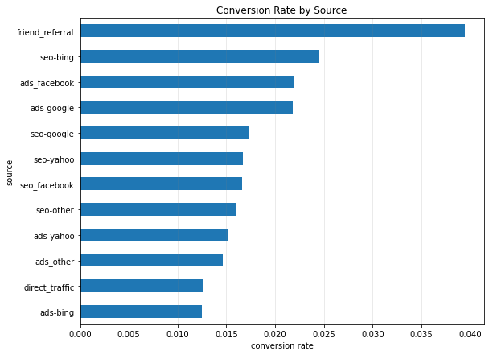

```python
test_results.groupby(["source"])["converted"]\
            .mean()\
            .sort_values(ascending=True)\
            .plot.barh(title = 'Conversion Rate by Source',
                       legend = False,
                       figsize =(9,7))
plt.xlabel('conversion rate')
plt.grid(True,axis='x',color='grey',alpha=0.2)
```

```
(array([0, 1]), [Text(0, 0, 'web'), Text(1, 0, 'mobile')])
```

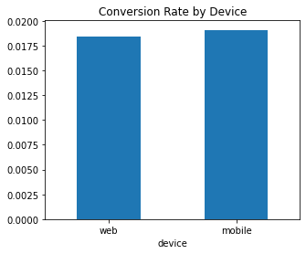

```python
test_results.groupby(["device"])["converted"]\
            .mean()\
            .sort_values(ascending=True)\
            .plot.bar(title = 'Conversion Rate by Device',
                       legend = False,
                       figsize =(5,4))
plt.xticks(rotation = 0)
```

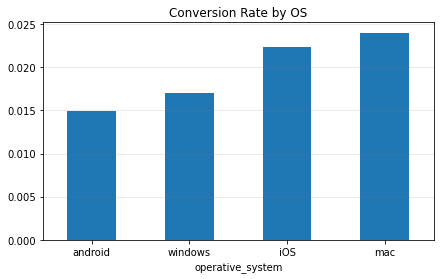

```python
test_results.groupby(["operative_system"])["converted"]\
            .mean()\
            .sort_values(ascending=True)\
            .plot.bar(title = 'Conversion Rate by OS',
                       legend = False,
                       figsize =(7,4))
plt.xticks(rotation = 0)
plt.grid(True,axis='y',color='grey',alpha=0.2)
```

## Problem 2: At which price should the company list its software?

```python
# examine number of conversions for each group
test_results.groupby(["test"])["user_id"].count()
```

```
test
0    189640
1    106201
Name: user_id, dtype: int64
```

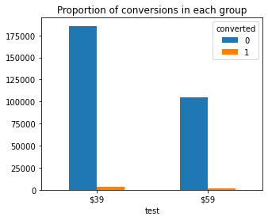

```python
test_results.groupby(["test"])["converted"].value_counts(normalize=False).unstack(
'converted').plot(kind="bar", stacked=False, figsize=(5,4));
plt.xticks(np.arange(2), ["$39","$59"],rotation=0)
plt.title("Proportion of conversions in each group");
```

More converted when the price was 39 compared to 59,but the sample size in each group was unequal.

So this alone does not mean 39 is better. There is a cost-benefit trade-off to examine and we need to figure out the conversion rate first.

For each group, we define the conversion rate as the proportion of each group bought the software.

```python
conv = test_results.groupby("test").converted.value_counts(normalize = False)
conv
```

```
test  converted
0     0            185790
      1              3850
1     0            104492
      1              1709
Name: converted, dtype: int64
```

```python
val_counts = test_results.groupby("test")["converted"].value_counts(normalize=True)
val_counts
```

```
test  converted
0     0            0.979698
      1            0.020302
1     0            0.983908
      1            0.016092
Name: converted, dtype: float64
```

```python
print("The conversion rate for the $39 group:", round(val_counts[0,1]*100,2),"%")
print("The conversion rate for the $59 group:", round(val_counts[1,1]*100,2),"%")
```

```
The conversion rate for the $39 group: 2.03 %
The conversion rate for the $59 group: 1.61 %
```

### How much money would the company make from all converted users at each price?

```python
print("Estimated revenue made by charging at $39:",conv[0,1]*39)
print("Estimated revenue made by charging at $59:",conv[1,1]*59)
```

```
Estimated revenue made by charging at $39: 150150
Estimated revenue made by charging at $59: 100831
```

### How much money would the company make from each user at each price?

```python
print("Estimated revenue per user by charging at $39:",round(39*val_counts[0,1],2))
print("Estimated revenue per user by charging at $59:",round(59*val_counts[1,1],2))
```

```
Estimated revenue per user by charging at $39: 0.79
Estimated revenue per user by charging at $59: 0.95
```

### Are the conversion rate in each group statistically different?

We define based on the business that if the conversion rate of 39 dollar is 5% higher than that of 59 dollar, we could call it that the conversion rate is significantly different and should be avoided.

```python
from statsmodels.stats.proportion import proportions_ztest
count = np.array(val_counts[0,1],val_counts[1,1])
nobs = np.array(val_counts[0,0]+val_counts[0,1],val_counts[1,0]+val_counts[1,1])
value = .05

stat,pval = proportions_ztest(count,nobs,value,alternative = "smaller")
print("pvalue is", pval)
```

```
pvalue is 0.41660675462223284
```

There is no significant 5% conversion rate difference for having a higher price found via a z-test

Because the higher conversion rate brought by 39 dollar is no 5% higher than that of 59 dollar. It would be more reasonable to keep the price at 59 dollar

## Problem 3: How long should the test have been run for to achieve statistically significant results?

```python
import statsmodels.stats.api as sms
# effect size for a test comparing two proportions
es = sms.proportion_effectsize(val_counts[0,1],val_counts[1,1])
sample_ = sms.NormalIndPower().solve_power(es, power=0.8, alpha=0.05, ratio=1)
print("Need a sample size per group of:", round(sample_,0))
print("Need total user sample of:", round(sample_,0)*2)
```

```
Need a sample size per group of: 15774.0
Need total user sample of: 31548.0
```

```python
test_results["timestamp"] = pd.to_datetime(test_results.timestamp,format="%Y-%m-%d %H:%M:%S",errors="coerce")
```

```python
users_per_day = test_results.set_index("timestamp").resample("D").user_id.count().mean()
print("Average users per day:", round(users_per_day,2))
print("Days needed for experiment:", round(sample_/users_per_day,2))
```

```
Average users per day: 3142.67
Days needed for experiment: 5.02
```

The total time needed for the experiment is 5 days.  
But I would recommend longer 2 weeks due to variations in user activity based on day of the week.

The end